# ME613 - Análise de Regressão

## Transformações

## Transformações: relações não lineares

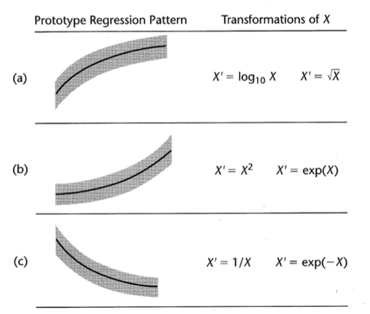

## Exemplo: Treinamento e Performance

\(X\): número de dias de treinamento recebido.

\(Y\): performance nas vendas.

```
##    Days Performance
## 1   0.5        42.5
## 2   0.5        50.6
## 3   1.0        68.5
## 4   1.0        80.7
## 5   1.5        89.0
## 6   1.5        99.6
## 7   2.0       105.3
## 8   2.0       111.8
## 9   2.5       112.3
## 10  2.5       125.7
```

## Exemplo: Treinamento e Performance

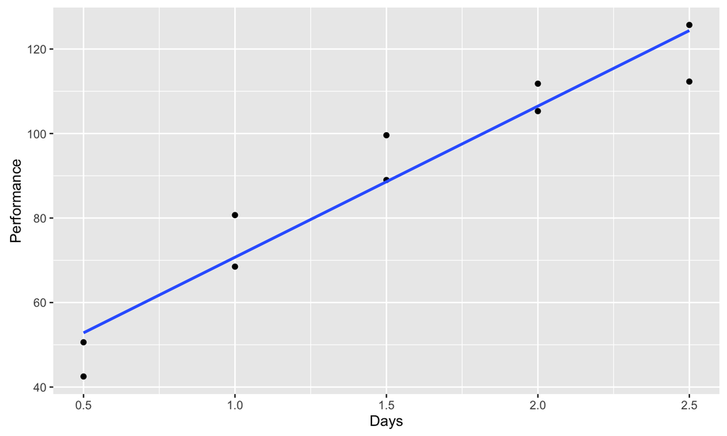

\[\hat{Y}=34.945 + 35.77X\]

## Exemplo: Treinamento e Performance

Gráfico de resíduos: \(e_i\) versus \(\hat{Y}_i\).

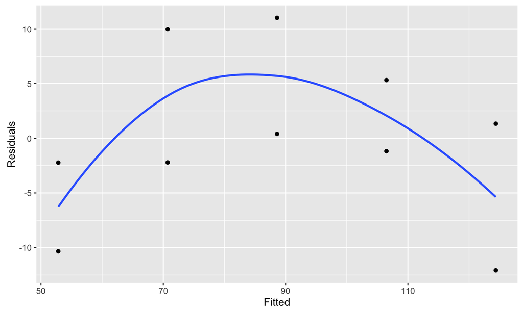

## Exemplo: Treinamento e Performance

\(X'=\sqrt{X}\)

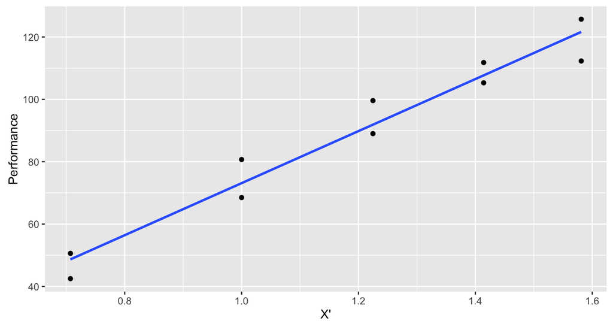

\[\hat{Y}=-10.33 + 83.45\sqrt{X}\]

## Exemplo: Treinamento e Performance

Gráfico de resíduos: \(e_i\) versus \(\hat{Y}_i\) usando \(X'\) no modelo.

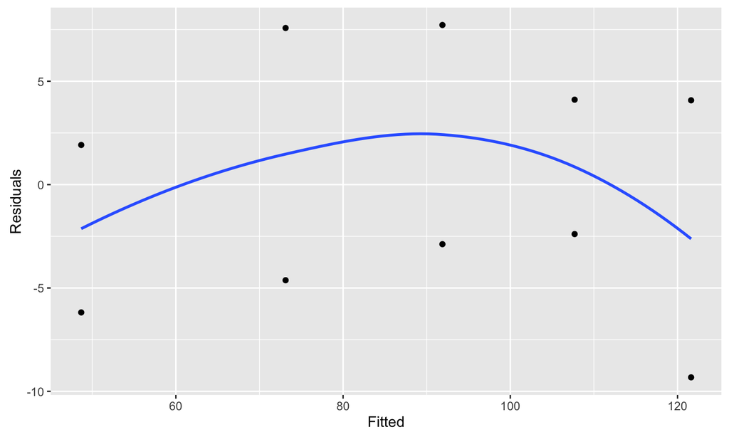

## Transformações: não normalidade e variância não constante

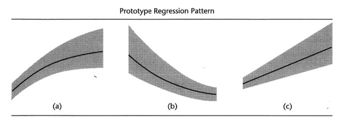

## Transformações: não normalidade e variância não constante

- Tentar encontrar transformação em \(Y\).
- Pode ser combinada com uma transformação também em \(X\).

## Exemplo: Idade e nível de poliamina

\(X\): Idade

\(Y\): nível de poliamina no plasma

```
##    Idade Poliamina
## 1      0     13.44
## 2      0     12.84
## 3      0     11.91
## 4      0     20.09
## 5      0     15.60
## 6      1     10.11
## 7      1     11.38
## 8      1     10.28
## 9      1      8.96
## 10     1      8.59
## 11     2      9.83
## 12     2      9.00
## 13     2      8.65
## 14     2      7.85
## 15     2      8.88
## 16     3      7.94
## 17     3      6.01
## 18     3      5.14
## 19     3      6.90
## 20     3      6.77
## 21     4      4.86
## 22     4      5.10
## 23     4      5.67
## 24     4      5.75
## 25     4      6.23
```

## Exemplo: Idade e nível de poliamina

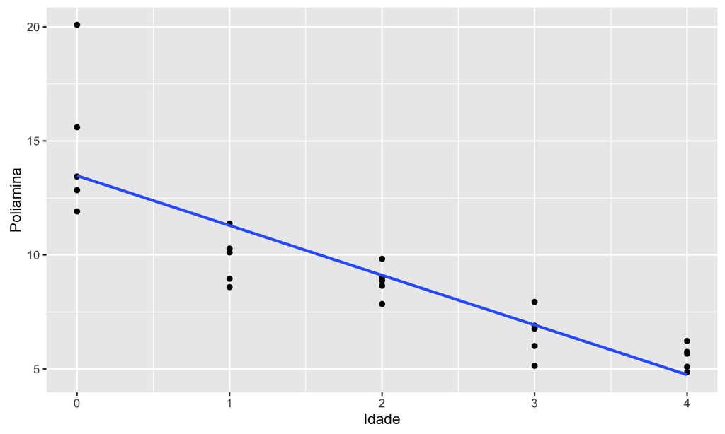

\[\hat{Y}=13.4752 + -2.182X\]

## Exemplo: Idade e nível de poliamina

Gráfico de resíduos: \(e_i\) versus \(\hat{Y}_i\).

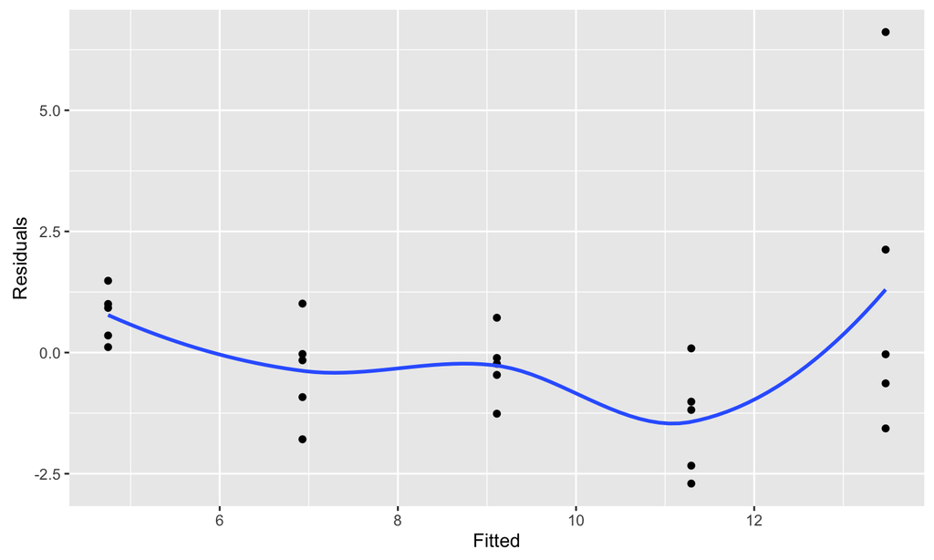

## Exemplo: Idade e nível de poliamina

Gráfico de resíduos: \(e_i\) versus \(X_i\).

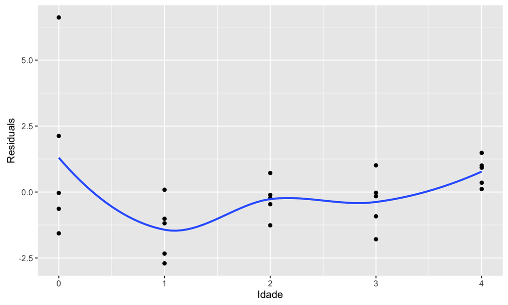

## Exemplo: Idade e nível de poliamina

\(Y'=\log_{10}Y\)

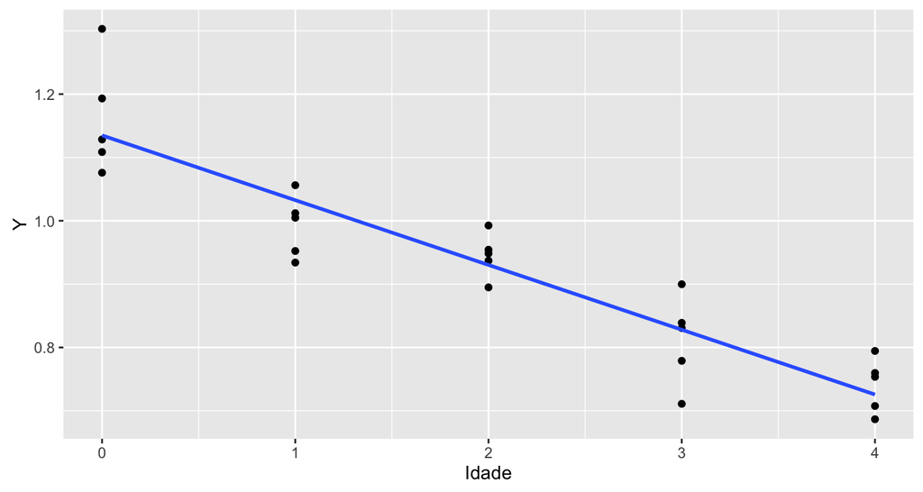

\[\hat{Y'}=1.13 + -0.1X\]

## Exemplo: Idade e nível de poliamina

Gráfico de resíduos: \(e_i\) versus \(\hat{Y'}_i\) usando \(Y'\) no modelo.

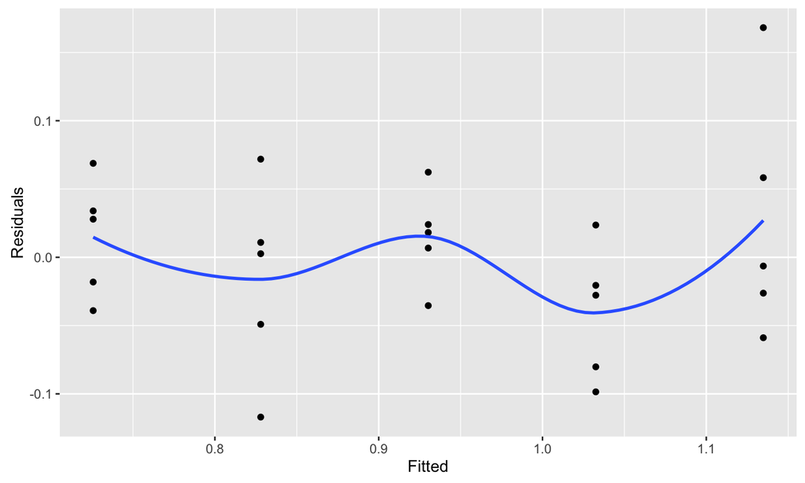

## Exemplo: Idade e nível de poliamina

Gráfico de resíduos: \(e_i\) versus \(X_i\).

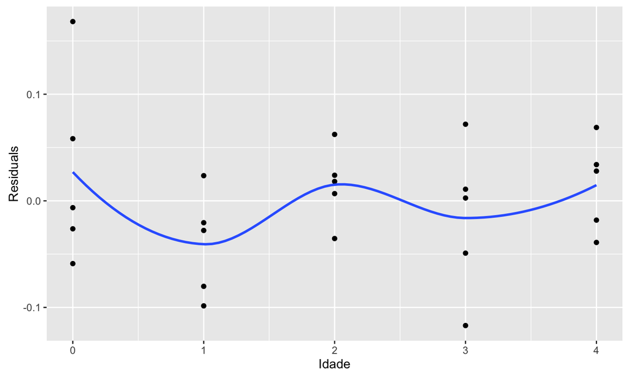

## Algumas transformações em \(Y\)

- \(\log_e(Y)\): para estabilizar a variância quando esta tende a crescer à medida que \(Y\) cresce.
- \(\sqrt{Y}\): estabilizar a variância quando esta é proporcional à média dos \(Y\)'s.
- \(\frac{1}{Y}\): estabilizar a variância, minimizando o efeito de valores muito altos de \(Y\).
- \(Y^2\): estabilizar a variância quando esta tende a decrescer com a média de \(Y\)'s.
- \(\arcsin{\sqrt{Y}}\): estabilizar a variância quando os dados são proporções.
- etc…

## Transformações de Box-Cox

- Muitas vezes é difícil determinar, através de gráficos, qual a melhor transformação a ser feita.
- O procedimento de [Box-Cox](http://www.jstor.org/stable/2984418) identifica automaticamente uma transformação:

\[Y'=Y^{\lambda}\]

em que \(\lambda\) é um parâmetro a ser determinado a partir dos dados.

- Modelo com dados transformados:

\[Y_i^{\lambda}=\beta_0+\beta_1X_i+\varepsilon_i\]

- O procedimento de Box-Cox utiliza o método de máxima verossimilhança para estimar \(\lambda\).

## Leitura

- Applied Linear Statistical Models: 3.8-3.11.
- Weisberg - Applied Linear Regression: Capítulo 8.
- Faraway - [Linear Models with R](http://www.maths.bath.ac.uk/~jjf23/LMR/): Capítulo 9.

[figure not shown]